# Explaining alcohol effects on academic performence using SHAP

## Task A

In this homework I'll explain performance of portugeese students (secondary education). The dataset will not differ from the [the previous homework](https://github.com/mim-uw/eXplainableMachineLearning-2023/blob/main/Homeworks/HW1/EmiliaWi%C5%9Bnios/XAI_lab1.ipynb).

1. Train a tree-based ensemble model on the selected dataset; it can be one of random forest, GBM, CatBoost, XGBoost, LightGBM (various types) etc.
2. Select two observations from the dataset and calculate the model's prediction.
3. Next, for the same observations, calculate the decomposition of predictions, so-called variable attributions, using SHAP from two packages of choice, e.g. for Python: `dalex` and `shap`, for R: `DALEX` and `iml`.
4. Find any two observations in the dataset, such that they have different variables of the highest importance, e.g. age and gender have the highest (absolute) attribution for observation A, but race and class are more important for observation B.
5. (If possible) Select one variable X and find two observations in the dataset such that for one observation, X has a positive attribution, and for the other observation, X has a negative attribution.
6. (How) Do the results differ across the two packages selected in point (3)?
7. (Using one explanation package of choice) Train another model of any class: neural network, linear model, decision tree etc. and find an observation for which SHAP attributions are different between this model and the one trained in point (1).
8. Comment on the results obtained in points (4)-(7)

ad. 1.

This time I've decided not to join math and portugeese dataset, but to do separate models and check if there are any noticible differences in explanations between them. All categorical variables were one-hot-encoded due to problems with libraries. I've used xgboost model from `xgboost` library.

ad. 2.

I've chosen observations randomly (and hardcoded in code so that it still remains reproducable). What is worth observing is the difference in distributions of academic performance on math and portugeese.

Math:

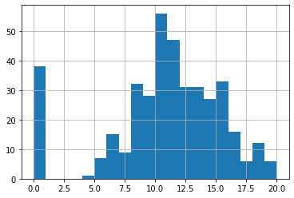

Portugeese:

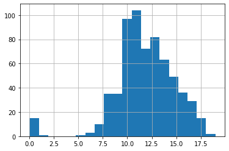

After plotting thoses distributions I was sure that checking that dataset separetly was better than joining them due to shift in distribution (it was probably easier to get a good mark in portugeese than in math).

ad. 3.

I've decided to use `dalex` package and `shap` package for explaining instances. For my instances I got following plots:

- For math dataset

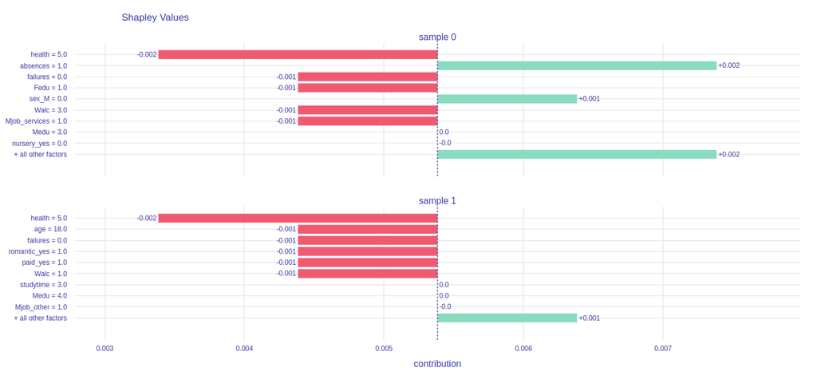

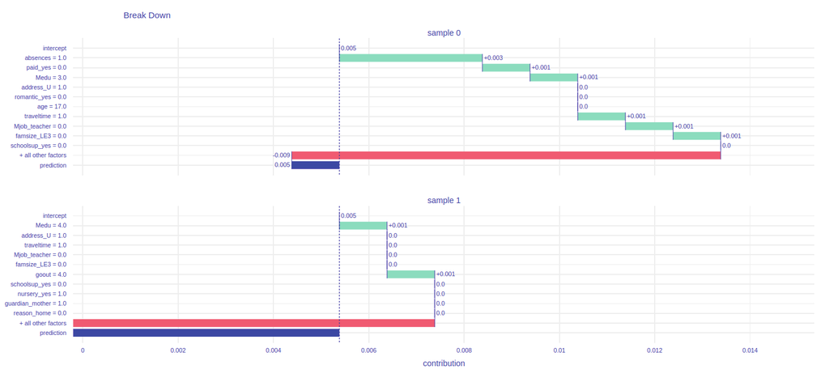

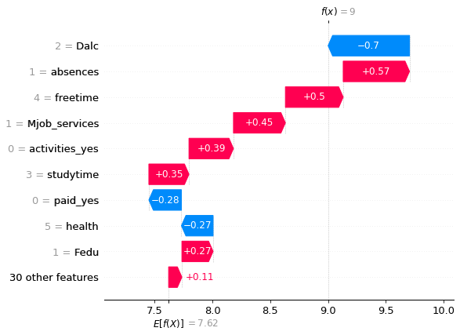

And some global explanaitions

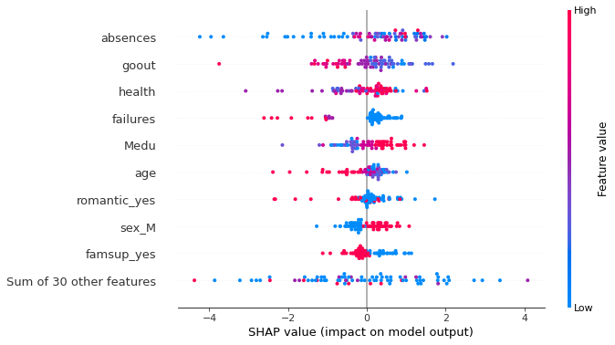

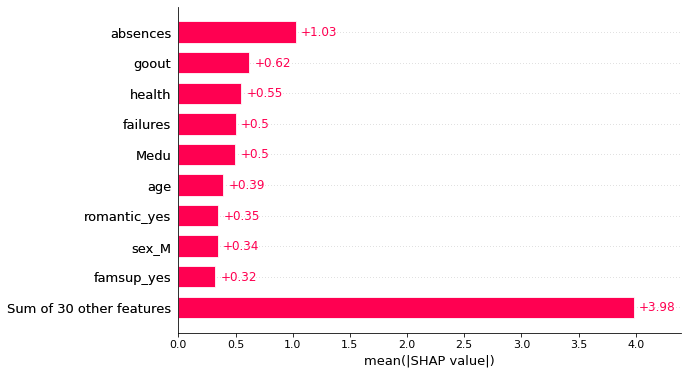

- For portugeese dataset

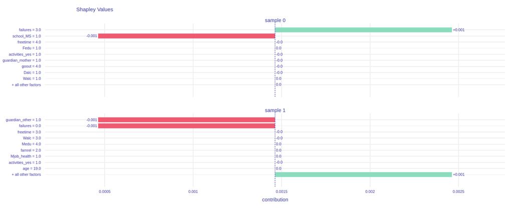

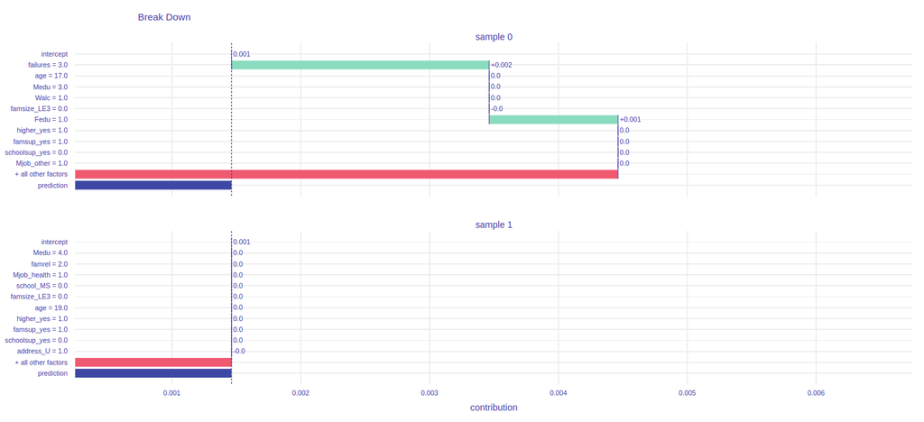

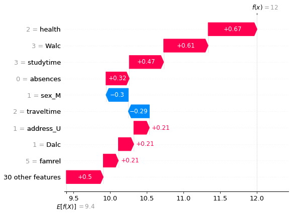

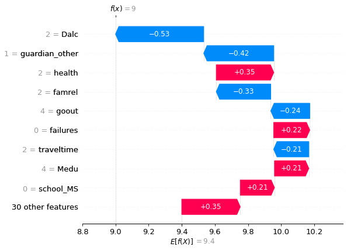

And some global explanaitions:

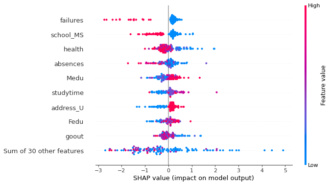

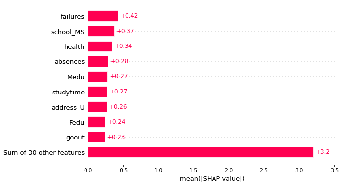

ad. 4.

- For math dataset

- For portugeese dataset

From `shap` package we have: for the first sample (health, Walc -- weekend alcohol consumption, studytime), for the second sample (Dalc, guardian_other, health). We can see that health is important in both cases but other features are compeletly different.

From `dalex` package: for the first sample (failures, school_MS, freetime), for the second sample (guardian_other, failures, freetime)

ad. 5.

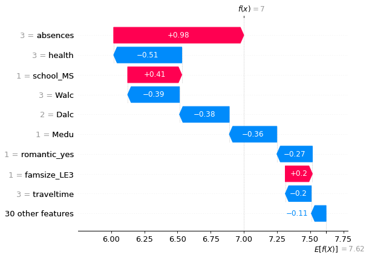

ad. 6.

The most important thing is that they differ in shaply values. I guess that both of them are sampled shapley values so they may have different ways of sampling instances.

They also differ in a method of plotting the results.

ad. 7.

I've used `dalex` package for the first observation of math dataset. The second model I've used was SVM. By looking at the shap values, I can see that SVM may not be the best model for this task.

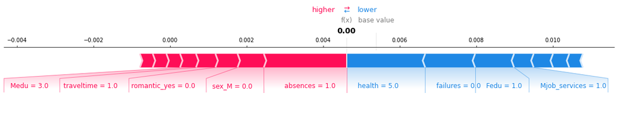

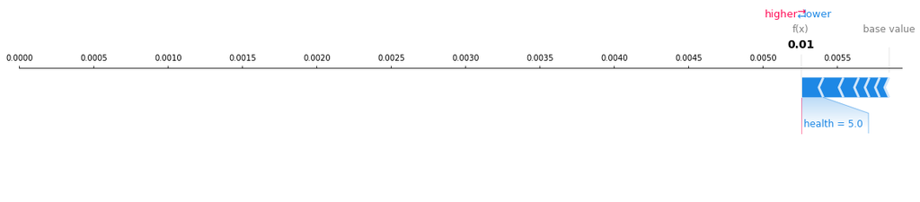

The only value that matters for the SVM model is health. Explanation from xgboost model is reacher, more complex and more informative (in context of explaining model's decision).

ad. 8. Done :)

## Task B

Calculate Shapley values for player A given the following value function

```
v() = 0
v(A) = 20
v(B) = 20
v(C) = 60
v(A,B) = 60
v(A,C) = 70
v(B,C) = 70
v(A,B,C) = 100
```

Solution:

$\phi_A = \frac{1}{6} \cdot \left(2 \cdot 20 + 40 + 10 + 2 \cdot 30 \right) = 25$

Explanaition:

- When A is the first in the group it brings 20 to the group. We have two cases like that (ABC, ACB)
- When B is first in the group and A is second we have: $60 - 20 = 40$
- When C is first in the group and A is second we have: $70 - 60 = 10$
- When A is the last one in the group we have: $100 - 70 = 30$. We have two cases like that (BCA, CBA).

# Appendix

### Setup

```python
!pip install shap >/dev/null 2>&1
!pip install dalex >/dev/null 2>&1
!pip install 'xgboost==1.6.2' >/dev/null 2>&1
```

```python
import pandas as pd
from sklearn.model_selection import train_test_split
import matplotlib.pyplot as plt
from sklearn.linear_model import LogisticRegression
import xgboost as xgb
import shap
import numpy as np
import dalex
from sklearn.metrics import classification_report
from sklearn.svm import SVC
```

```python
from google.colab import files
files.upload()
print(' ')
```

Upload widget is only available when the cell has been executed in the current browser session. Please rerun this cell to enable.

```
Saving archive.zip to archive (1).zip
```

```python
! unzip archive.zip -d data
```

```
Archive:  archive.zip
replace data/Maths.csv? [y]es, [n]o, [A]ll, [N]one, [r]ename: y
  inflating: data/Maths.csv
replace data/Portuguese.csv? [y]es, [n]o, [A]ll, [N]one, [r]ename: y
  inflating: data/Portuguese.csv
```

### Data preparation

```python
df_math = pd.read_csv('/content/data/Maths.csv')
df_port = pd.read_csv('/content/data/Portuguese.csv')
```

```python
def get_one_hot_columns(df):
  one_hot_columns = []
  for column in df.columns:
    if df[column].dtype == 'object':
      one_hot_columns.append(column)
  return one_hot_columns
```

```python
df_math = pd.get_dummies(df_math, columns=get_one_hot_columns(df_math), drop_first=True)
df_port = pd.get_dummies(df_port, columns=get_one_hot_columns(df_port), drop_first=True)
```

```python
X_math = df_math.copy()
X_math = X_math.drop(['G3', 'G2', 'G1'], axis=1)
y_math = df_math['G3']

X_port = df_port.copy()
X_port = X_port.drop(['G3', 'G2', 'G1'], axis=1)
y_port = df_port['G3']
```

```python
prev = list(set(y_math))
```

```python
from sklearn.preprocessing import LabelEncoder
le = LabelEncoder()
y_math = le.fit_transform(y_math)
y_port = le.fit_transform(y_port)
```

```python
encoded = list(set(y_math))
```

```python
encoded_to_prev_label = {}
for p, e in zip(prev, encoded):
  encoded_to_prev_label[e] = p
```

```python
df_math.dropna(inplace=True)
df_port.dropna(inplace=True)
```

```python
X_math_train, X_math_test, y_math_train, y_math_test = train_test_split(X_math, y_math, test_size=0.2, random_state=42)
X_port_train, X_port_test, y_port_train, y_port_test = train_test_split(X_port, y_port, test_size=0.2, random_state=42)
```

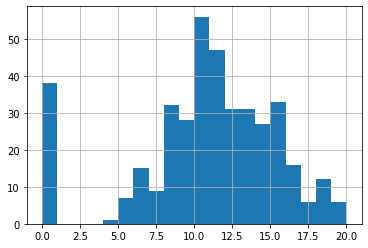

```python
df_math['G3'].hist(bins=20)
```

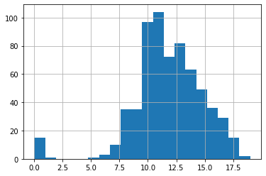

```python
df_port['G3'].hist(bins=20)
```

## Model for math

```python
xgb_math = xgb.XGBClassifier(
    n_estimators=200,
    max_depth=4,
    use_label_encoder=False,
    eval_metric="logloss",
    enable_categorical=False,
    tree_method="hist"
)
```

```python
xgb_math.fit(X_math_train, y_math_train)
```

```
XGBClassifier(base_score=0.5, booster='gbtree', callbacks=None,
              colsample_bylevel=1, colsample_bynode=1, colsample_bytree=1,
              early_stopping_rounds=None, enable_categorical=False,
              eval_metric='logloss', gamma=0, gpu_id=-1,
              grow_policy='depthwise', importance_type=None,
              interaction_constraints='', learning_rate=0.300000012,
              max_bin=256, max_cat_to_onehot=4, max_delta_step=0, max_depth=4,
              max_leaves=0, min_child_weight=1, missing=nan,
              monotone_constraints='()', n_estimators=200, n_jobs=0,
              num_parallel_tree=1, objective='multi:softprob', predictor='auto',
              random_state=0, reg_alpha=0, ...)
```

```python
# sample1 = np.random.randint(len(X_math_test))
# sample2 = np.random.randint(len(X_math_test))
# print(sample1, sample2)
```

```
12 68
```

```python
sample1 = 12
sample2 = 68
```

```python
encoded_to_prev_label[xgb_math.predict(X_math_test.take([sample1]), y_math_test.take([sample1])).argmax(axis=-1).item()]
```

```
12
```

```python
encoded_to_prev_label[xgb_math.predict(X_math_test.take([sample2]), y_math_test.take([sample2])).argmax(axis=-1).item()]
```

```
11
```

```python
X_math_sample = X_math_test.take([sample1, sample2])
X_math_sample = X_math_sample.reset_index(drop=True)
```

### Dalex for math

```python
explainer = dalex.Explainer(xgb_math, X_math_test, y_math_test, label="GBM")
```

```
Preparation of a new explainer is initiated

  -> data              : 79 rows 39 cols
  -> target variable   : 79 values
  -> model_class       : xgboost.sklearn.XGBClassifier (default)
  -> label             : GBM
  -> predict function  : <function yhat_proba_default at 0x7fba861f49e0> will be used (default)
  -> predict function  : Accepts pandas.DataFrame and numpy.ndarray.
  -> predicted values  : min = 0.000321, mean = 0.00538, max = 0.0373
  -> model type        : classification will be used (default)
  -> residual function : difference between y and yhat (default)
  -> residuals         : min = -0.00646, mean = 7.96, max = 16.0
  -> model_info        : package xgboost

A new explainer has been created!
```

```python
pred = xgb_math.predict(X_math_test)
print(classification_report(y_math_test, pred, zero_division=0))
```

```
              precision    recall  f1-score   support

           0       0.44      0.80      0.57         5
           2       0.00      0.00      0.00         4
           3       0.00      0.00      0.00         6
           4       0.00      0.00      0.00         1
           5       0.17      0.17      0.17         6
           6       0.00      0.00      0.00         5
           7       0.23      0.27      0.25        11
           8       0.00      0.00      0.00         5
           9       0.14      0.20      0.17         5
          10       0.00      0.00      0.00         5
          11       0.33      0.17      0.22         6
          12       0.17      0.10      0.12        10
          13       0.17      0.25      0.20         4
          14       0.00      0.00      0.00         3
          15       0.00      0.00      0.00         1
          16       0.00      0.00      0.00         2

    accuracy                           0.15        79
   macro avg       0.10      0.12      0.11        79
weighted avg       0.14      0.15      0.14        79
```

```python
explainer.predict(X_math_sample)
shap_attributions = [explainer.predict_parts(X_math_sample.iloc[[i]], type="shap", label=f'sample {i}') for i in range(len(X_math_sample))]
shap_attributions[0].plot(shap_attributions[1::])
```

[interactive chart not shown]

```python
shap_attributions = [explainer.predict_parts(X_math_sample.iloc[[i]], type="break_down", label=f'sample {i}') for i in range(len(X_math_sample))]
shap_attributions[0].plot(shap_attributions[1::])
```

[interactive chart not shown]

### Shap for math

```
Permutation explainer: 80it [00:56,  1.18it/s]
```

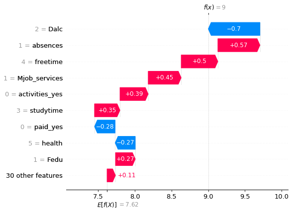

```python
explainer = shap.Explainer(xgb_math.predict, X_math_test, model_output='probability')
shap_values = explainer(X_math_test)
shap.plots.waterfall(shap_values[sample1])
```

```python
shap.plots.waterfall(shap_values[sample2])
```

[output not shown]

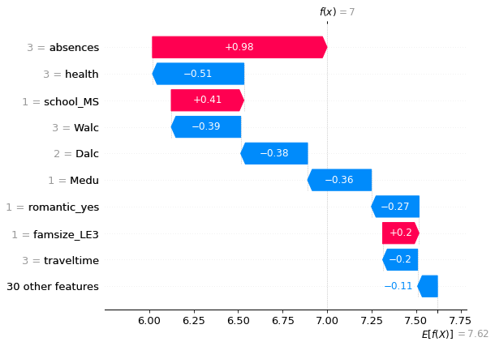

```python
sample3 = 1
shap.plots.waterfall(shap_values[sample3])
```

### Global explanaitions for SHAP

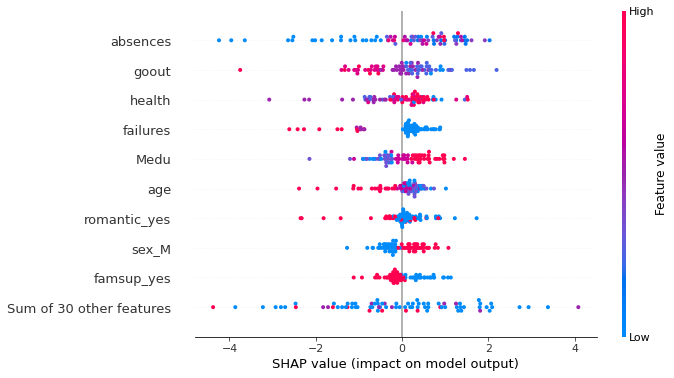

```python
shap.plots.beeswarm(shap_values, max_display=10, plot_size=(9, 6))
```

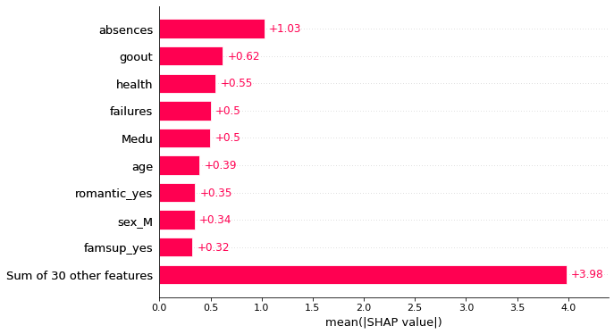

```python
import matplotlib.pyplot as plt
# plots.bar() has no plot_size parameter
shap.plots.bar(shap_values, max_display=10, show=False)
plt.gcf().set_size_inches(9, 6)
plt.show()
```

### Second model

```python
svm_math = SVC(probability=True)
svm_math.fit(X_math_train, y_math_train)
```

```
SVC(probability=True)
```

```python
exp_svm_math = dalex.Explainer(svm_math, X_math_test, label="SVM", verbose=False)
exp_xgboost_math = dalex.Explainer(xgb_math, X_math_test, label="GBM", verbose=False)
```

```python
sv_svm = [exp_svm_math.predict_parts(X_math_test.iloc[[i]], type="shap_wrapper") for i in [sample1, sample2]]
```

[output not shown]

```python
sv_xgboost = [exp_xgboost_math.predict_parts(X_math_test.iloc[[i]], type="shap_wrapper") for i in [sample1, sample2]]
```

```
====  Sample 0  ====
----  XGBoost:
```

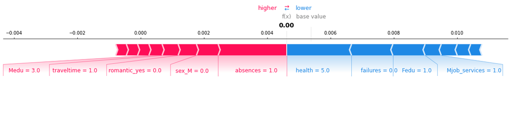

```
---- SVM:
```

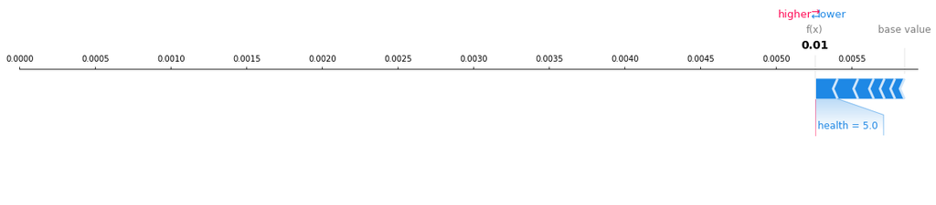

```
====  Sample 1  ====
----  XGBoost:
```

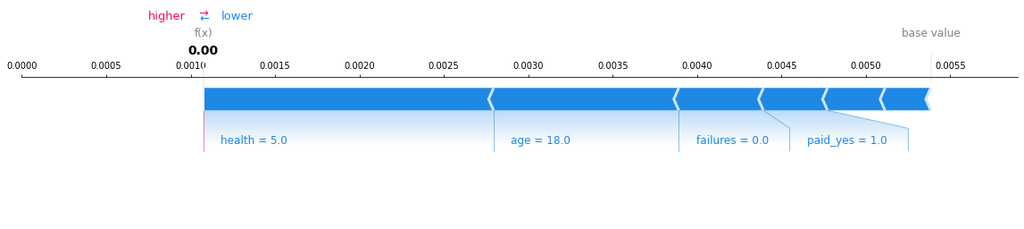

```
---- SVM:
```

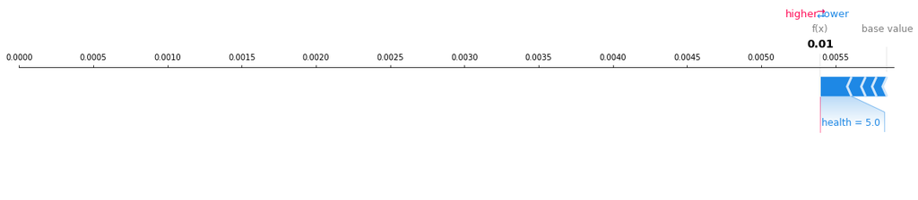

```python
for i in range(2):
    print(f'====  Sample {i}  ====')
    print('----  XGBoost:')
    sv_xgboost[i].plot()
    print('---- SVM:')
    sv_svm[i].plot()
```

## Model for portugeese

```python
xgb_port = xgb.XGBClassifier(
    n_estimators=200,
    max_depth=4,
    use_label_encoder=False,
    eval_metric="logloss",
    enable_categorical=False,
    tree_method="hist"
)
```

```python
xgb_port.fit(X_port_train, y_port_train)
```

```
XGBClassifier(base_score=0.5, booster='gbtree', callbacks=None,
              colsample_bylevel=1, colsample_bynode=1, colsample_bytree=1,
              early_stopping_rounds=None, enable_categorical=False,
              eval_metric='logloss', gamma=0, gpu_id=-1,
              grow_policy='depthwise', importance_type=None,
              interaction_constraints='', learning_rate=0.300000012,
              max_bin=256, max_cat_to_onehot=4, max_delta_step=0, max_depth=4,
              max_leaves=0, min_child_weight=1, missing=nan,
              monotone_constraints='()', n_estimators=200, n_jobs=0,
              num_parallel_tree=1, objective='multi:softprob', predictor='auto',
              random_state=0, reg_alpha=0, ...)
```

```python
# sample3 = np.random.randint(len(X_port_test))
# sample4 = np.random.randint(len(X_port_test))
# print(sample3, sample4)
```

```
67 22
```

```python
sample3 = 67
sample4 = 22
```

```python
encoded_to_prev_label[xgb_port.predict(X_port_test.take([sample3]), y_port_test.take([sample3])).argmax(axis=-1).item()]
```

```
8
```

```python
encoded_to_prev_label[xgb_port.predict(X_port_test.take([sample4]), y_port_test.take([sample4])).argmax(axis=-1).item()]
```

```
12
```

```python
X_port_sample = X_port_test.take([sample3, sample4])
X_port_sample = X_port_sample.reset_index(drop=True)
```

### Dalex for portugeese

```python
explainer = dalex.Explainer(xgb_port, X_port_test, y_port_test, label="GBM")
```

```
Preparation of a new explainer is initiated

  -> data              : 130 rows 39 cols
  -> target variable   : 130 values
  -> model_class       : xgboost.sklearn.XGBClassifier (default)
  -> label             : GBM
  -> predict function  : <function yhat_proba_default at 0x7fba861f49e0> will be used (default)
  -> predict function  : Accepts pandas.DataFrame and numpy.ndarray.
  -> predicted values  : min = 1.12e-05, mean = 0.00146, max = 0.0134
  -> model type        : classification will be used (default)
  -> residual function : difference between y and yhat (default)
  -> residuals         : min = -0.0134, mean = 9.4, max = 16.0
  -> model_info        : package xgboost

A new explainer has been created!
```

```python
pred = xgb_port.predict(X_port_test)
print(classification_report(y_port_test, pred, zero_division=0))
```

```
              precision    recall  f1-score   support

           0       0.00      0.00      0.00         2
           3       0.00      0.00      0.00         0
           4       0.00      0.00      0.00         1
           5       0.00      0.00      0.00         7
           6       0.00      0.00      0.00         5
           7       0.10      0.18      0.13        17
           8       0.20      0.20      0.20        25
           9       0.14      0.19      0.16        16
          10       0.30      0.23      0.26        13
          11       0.18      0.17      0.17        12
          12       0.08      0.10      0.09        10
          13       0.00      0.00      0.00         9
          14       0.12      0.20      0.15         5
          15       0.00      0.00      0.00         7
          16       0.00      0.00      0.00         1

    accuracy                           0.14       130
   macro avg       0.08      0.08      0.08       130
weighted avg       0.13      0.14      0.13       130
```

```python
explainer.predict(X_port_sample)
shap_attributions = [explainer.predict_parts(X_port_sample.iloc[[i]], type="shap", label=f'sample {i}') for i in range(len(X_port_sample))]
shap_attributions[0].plot(shap_attributions[1::])
```

[interactive chart not shown]

```python
shap_attributions = [explainer.predict_parts(X_port_sample.iloc[[i]], type="break_down", label=f'sample {i}') for i in range(len(X_port_sample))]
shap_attributions[0].plot(shap_attributions[1::])
```

[interactive chart not shown]

### Shap for portugeese

```
Permutation explainer: 131it [02:04,  1.00s/it]
```

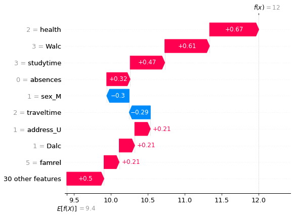

```python
explainer = shap.Explainer(xgb_port.predict, X_port_test, model_output='probability')
shap_values = explainer(X_port_test)
shap.plots.waterfall(shap_values[sample3])
```

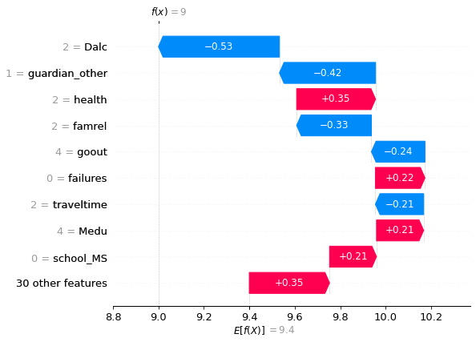

```python
shap.plots.waterfall(shap_values[sample4])
```

### Global explanaitions for SHAP

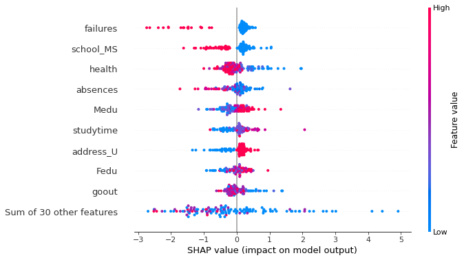

```python
shap.plots.beeswarm(shap_values, max_display=10, plot_size=(9, 6))
```

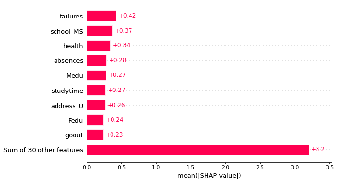

```python
import matplotlib.pyplot as plt
# plots.bar() has no plot_size parameter
shap.plots.bar(shap_values, max_display=10, show=False)
plt.gcf().set_size_inches(9, 6)
plt.show()
```